# Summary of colocalization analysis

Silva Kasela

06/01/2020

For colocalization analysis including eQTL data for genes that have an eQTL implicated in

- blood cell traits (*EFO parent category = Hematological measurement*)
- pulmonary function traits (*EFO parent category = Pulmonary function measurement*)
- respiratory system disease (*EFO parent category = Respiratory disease*)

Colocalization analysis:

- Using both the standard method and coloc-cond/mask
  - When using coloc-cond/mask, then using `method = mask` in the GWAS dataset and LD from the matching 1000G population (*for example, if discovery population is of European ancestry, then using 1000G CEU population for calculating LD*)
  - When using coloc-cond/mask, then using `method = single` in the eQTL dataset if the eGene does not have multiple independent eVaraints, otherwise using conditional p-values (*all the eGenes tested in coloc had only one independent eVariant*)
- Coloc in 500-kb region centered on lead eQTL (+/-250 kb from the lead variant)
- Priors p1 = 1e-4, p2 = 1e-4, p3 = 5e-6

```
## single : Could not get data from GWAS API or UKBB for  8
## eGene-GWAS traits pairs
## mask : Could not get data from GWAS API or UKBB for  8
## eGene-GWAS traits pairs
```

## Coloc-standard

- Number of eQTLs/genes and GWAS trait pairs used in colocalization analysis - 111

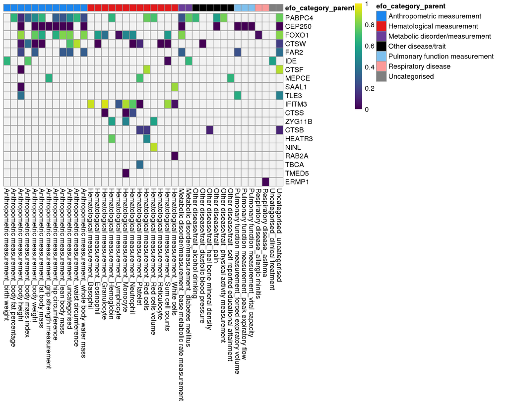

- Number of genes that have eQTLs colocalized with at least one GWAS trait - **12 genes**: CTSF, CTSW, FOXO1, HEATR3, IDE, IFITM3, MEPCE, NINL, PABPC4, SAAL1, TLE3, ZYG11B
- Number of genes that have eQTLs colocalized with at least one blood cell trait, pulmonary function trait, or respiratory system disease - **10 genes**: CTSF, FOXO1, HEATR3, IFITM3, MEPCE, NINL, PABPC4, SAAL1, TLE3, ZYG11B

| nsnps | PP.H0.abf | PP.H1.abf | PP.H2.abf | PP.H3.abf | PP.H4.abf | qtl | phenotype_id | qtl_lead_snv | qtl_lead_snv_pval | qtl_lead_snv_pos | gwas | gwas_lead_snv | gwas_lead_snv_pval | gwas_lead_snv_pos | gwas_hit_nearest_log10p_5 | chr | pos_phenotype | region_start | region_end | gwas_file | efo_category | efo_category_parent | id |
| --- | --- | --- | --- | --- | --- | --- | --- | --- | --- | --- | --- | --- | --- | --- | --- | --- | --- | --- | --- | --- | --- | --- | --- |
| 463 | 0.0001269 | 0.0156154 | 0.0008951 | 0.1084300 | 0.8749327 | cis_eqtl_bronch | CTSF | rs1815739 | 1.00e-07 | 66560624 | Astle_red_blood_cell_count | rs2444846 | 1.0e-07 | 66499235 | 0 | chr11 | 66568840 | 66310658 | 66810426 | GCST004601 | Red cells | Hematological measurement | CTSF_rs1815739_Astle_red_blood_cell_count |
| 948 | 0.0000000 | 0.0692798 | 0.0000000 | 0.3724509 | 0.5582693 | cis_eqtl_bronch | FOXO1 | rs61963323 | 2.00e-07 | 40688372 | Astle_eosinophil_percentage_of_white_cells | rs6563842 | 0.0e+00 | 40670160 | 0 | chr13 | 40666640 | 40440787 | 40939787 | GCST004600 | Eosinophil | Hematological measurement | FOXO1_rs61963323_Astle_eosinophil_percentage_of_white_cells |
| 948 | 0.0000000 | 0.0710447 | 0.0000000 | 0.3819904 | 0.5469649 | cis_eqtl_bronch | FOXO1 | rs61963323 | 2.00e-07 | 40688372 | Astle_sum_eosinophil_basophil_counts | rs9577091 | 0.0e+00 | 40653728 | 0 | chr13 | 40666640 | 40440787 | 40939787 | GCST004624 | Sum cell counts | Hematological measurement | FOXO1_rs61963323_Astle_sum_eosinophil_basophil_counts |
| 949 | 0.0005215 | 0.0653691 | 0.0013784 | 0.1712746 | 0.7614564 | cis_eqtl_bronch | HEATR3 | rs75157273 | 0.00e+00 | 50053521 | Astle_mean_corpuscular_hemoglobin | rs72794299 | 1.0e-07 | 50019449 | 0 | chr16 | 50065969 | 49803564 | 50302380 | GCST004630 | Hemoglobin | Hematological measurement | HEATR3_rs75157273_Astle_mean_corpuscular_hemoglobin |
| 1310 | 0.0000041 | 0.0123120 | 0.0000216 | 0.0631999 | 0.9244623 | cis_eqtl_bronch | IFITM3 | rs6421983 | 0.00e+00 | 320394 | Astle_white_blood_cell_count_(basophil) | rs7480524 | 0.0e+00 | 307696 | 0 | chr11 | 327536 | 196944 | 570280 | GCST004618 | Basophil | Hematological measurement | IFITM3_rs6421983_Astle_white_blood_cell_count_(basophil) |
| 1311 | 0.0000000 | 0.0097371 | 0.0000000 | 0.0495636 | 0.9406993 | cis_eqtl_bronch | IFITM3 | rs6421983 | 0.00e+00 | 320394 | Astle_granulocyte_percentage_of_myeloid_white_cells | rs7115703 | 0.0e+00 | 306920 | 0 | chr11 | 327536 | 196944 | 570280 | GCST004608 | Granulocyte | Hematological measurement | IFITM3_rs6421983_Astle_granulocyte_percentage_of_myeloid_white_cells |
| 1310 | 0.0000000 | 0.0187093 | 0.0000000 | 0.0970793 | 0.8842114 | cis_eqtl_bronch | IFITM3 | rs6421983 | 0.00e+00 | 320394 | Astle_monocyte_percentage_of_white_cells | rs10751647 | 0.0e+00 | 306884 | 0 | chr11 | 327536 | 196944 | 570280 | GCST004609 | Monocyte | Hematological measurement | IFITM3_rs6421983_Astle_monocyte_percentage_of_white_cells |
| 1311 | 0.0000000 | 0.0402600 | 0.0000000 | 0.2112138 | 0.7485262 | cis_eqtl_bronch | IFITM3 | rs6421983 | 0.00e+00 | 320394 | Astle_neutrophil_count | rs14408 | 0.0e+00 | 308314 | 0 | chr11 | 327536 | 196944 | 570280 | GCST004629 | Neutrophil | Hematological measurement | IFITM3_rs6421983_Astle_neutrophil_count |
| 1311 | 0.0000000 | 0.0227751 | 0.0000000 | 0.1186133 | 0.8586116 | cis_eqtl_bronch | IFITM3 | rs6421983 | 0.00e+00 | 320394 | Astle_sum_basophil_neutrophil_counts | rs14408 | 0.0e+00 | 308314 | 0 | chr11 | 327536 | 196944 | 570280 | GCST004620 | Sum cell counts | Hematological measurement | IFITM3_rs6421983_Astle_sum_basophil_neutrophil_counts |
| 500 | 0.0000000 | 0.1219548 | 0.0000000 | 0.1682581 | 0.7097871 | cis_eqtl_bronch | MEPCE | rs111757992 | 5.10e-06 | 100418731 | Astle_platelet_distribution_width | rs76913697 | 0.0e+00 | 100405149 | 0 | chr7 | 100428789 | 100169964 | 100668543 | GCST004616 | Platelet | Hematological measurement | MEPCE_rs111757992_Astle_platelet_distribution_width |
| 855 | 0.0019532 | 0.0021497 | 0.0453729 | 0.0481318 | 0.9023923 | cis_eqtl_bronch | NINL | rs8182757 | 0.00e+00 | 25562779 | Astle_mean_corpuscular_volume | rs8182757 | 3.5e-06 | 25562779 | 0 | chr20 | 25585530 | 25312934 | 25762594 | GCST004602 | Red cells volume | Hematological measurement | NINL_rs8182757_Astle_mean_corpuscular_volume |
| 869 | 0.0000000 | 0.1972085 | 0.0000000 | 0.1441759 | 0.6586156 | cis_eqtl_bronch | PABPC4 | rs111768751 | 4.00e-07 | 39580421 | Astle_mean_corpuscular_hemoglobin | rs113879410 | 0.0e+00 | 39607339 | 0 | chr1 | 39576789 | 39331383 | 39830208 | GCST004630 | Hemoglobin | Hematological measurement | PABPC4_rs111768751_Astle_mean_corpuscular_hemoglobin |
| 869 | 0.0009036 | 0.1644722 | 0.0006667 | 0.1199134 | 0.7140441 | cis_eqtl_bronch | PABPC4 | rs111768751 | 4.00e-07 | 39580421 | Astle_mean_corpuscular_volume | rs113879410 | 0.0e+00 | 39607339 | 0 | chr1 | 39576789 | 39331383 | 39830208 | GCST004602 | Red cells volume | Hematological measurement | PABPC4_rs111768751_Astle_mean_corpuscular_volume |
| 869 | 0.0000000 | 0.1289901 | 0.0000000 | 0.0936093 | 0.7774006 | cis_eqtl_bronch | PABPC4 | rs111768751 | 4.00e-07 | 39580421 | Astle_red_cell_distribution_width | rs3768321 | 0.0e+00 | 39570256 | 0 | chr1 | 39576789 | 39331383 | 39830208 | GCST004621 | Red cells | Hematological measurement | PABPC4_rs111768751_Astle_red_cell_distribution_width |
| 1140 | 0.0046203 | 0.0232916 | 0.0201115 | 0.0996793 | 0.8522973 | cis_eqtl_bronch | SAAL1 | rs7933259 | 1.00e-07 | 18074713 | Astle_white_blood_cell_count | rs11024458 | 1.0e-06 | 18060936 | 0 | chr11 | 18106086 | 17825834 | 18322517 | GCST004610 | White cells | Hematological measurement | SAAL1_rs7933259_Astle_white_blood_cell_count |
| 1244 | 0.0000001 | 0.3305542 | 0.0000000 | 0.0460408 | 0.6234048 | cis_eqtl_bronch | TLE3 | rs61999938 | 1.12e-05 | 70064221 | Neale_Forced_expiratory_volume_in_1-second_FEV1_predicted | rs61999938 | 0.0e+00 | 70064221 | 0 | chr15 | 70098175 | 69814392 | 70313862 | 20153_irnt.gwas.imputed_v3.both_sexes.tsv.bgz | forced expiratory volume | Pulmonary function measurement | TLE3_rs61999938_Neale_Forced_expiratory_volume_in_1-second_FEV1_predicted |
| 940 | 0.0000087 | 0.0924340 | 0.0000302 | 0.3179201 | 0.5896070 | cis_eqtl_bronch | ZYG11B | rs2065477 | 8.00e-07 | 52784541 | Astle_hematocrit | rs536621 | 0.0e+00 | 52843425 | 0 | chr1 | 52726452 | 52535576 | 53034221 | GCST004604 | Red cells volume | Hematological measurement | ZYG11B_rs2065477_Astle_hematocrit |
| 940 | 0.0062592 | 0.0896479 | 0.0216081 | 0.3083330 | 0.5741518 | cis_eqtl_bronch | ZYG11B | rs2065477 | 8.00e-07 | 52784541 | Astle_hemoglobin_concentration | rs536621 | 1.7e-06 | 52843425 | 0 | chr1 | 52726452 | 52535576 | 53034221 | GCST004615 | Hemoglobin | Hematological measurement | ZYG11B_rs2065477_Astle_hemoglobin_concentration |

## Coloc-cond/mask

- Number of eQTLs/genes and GWAS trait pairs used in colocalization analysis - 111

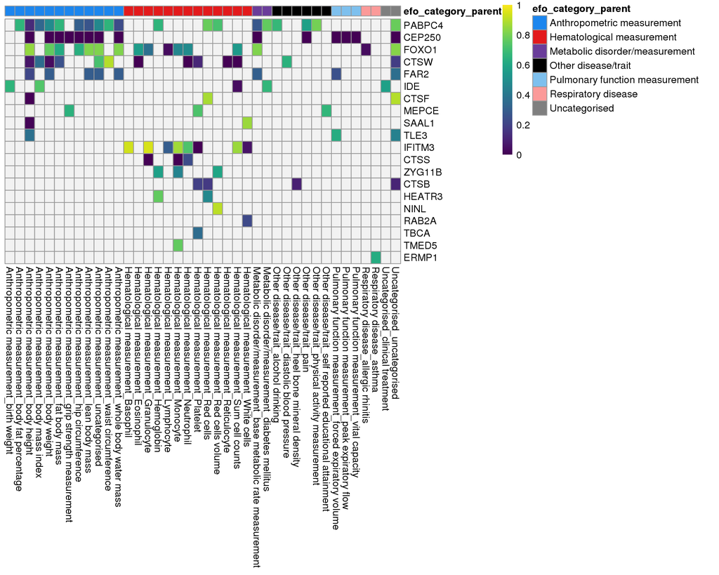

- Number of genes that have eQTLs colocalized with at least one GWAS trait - **14 genes** : CTSF, CTSW, ERMP1, FOXO1, HEATR3, IDE, IFITM3, MEPCE, NINL, PABPC4, SAAL1, TLE3, TMED5, ZYG11B
- Number of genes that have eQTLs colocalized with at least one blood cell trait, pulmonary function trait, or respiratory system disease - **12 genes**: CTSF, ERMP1, FOXO1, HEATR3, IFITM3, MEPCE, NINL, PABPC4, SAAL1, TLE3, TMED5, ZYG11B

| hit2 | hit1 | nsnps | PP.H0.abf | PP.H1.abf | PP.H2.abf | PP.H3.abf | PP.H4.abf | best1 | best2 | best4 | hit1.margz | hit2.margz | qtl | phenotype_id | qtl_lead_snv | qtl_lead_snv_pval | qtl_lead_snv_pos | gwas | gwas_lead_snv | gwas_lead_snv_pval | gwas_lead_snv_pos | gwas_hit_nearest_log10p_5 | chr | pos_phenotype | region_start | region_end | gwas_file | efo_category | efo_category_parent | … |
| --- | --- | --- | --- | --- | --- | --- | --- | --- | --- | --- | --- | --- | --- | --- | --- | --- | --- | --- | --- | --- | --- | --- | --- | --- | --- | --- | --- | --- | --- | --- |
| chr11_66563987 | chr11_66499235 | 453 | 0.0001558 | 0.0177443 | 0.0009270 | 0.1055830 | 0.8755899 | chr11_66499235 | chr11_66563987 | chr11_66570516 | 5.391557 | -5.515315 | cis_eqtl_bronch | CTSF | rs572846 | 2.00e-07 | 66563987 | Astle_red_blood_cell_count | rs2444846 | 1.0e-07 | 66499235 | 0 | chr11 | 66568840 | 66310658 | 66810426 | GCST004601 | Red cells | Hematological measurement | … |
| chr9_5817338 | chr9_5780803 | 823 | 0.0005468 | 0.0472617 | 0.0037272 | 0.3220870 | 0.6263772 | chr9_5665343 | chr9_5817338 | chr9_5780803 | 5.373028 | 5.562661 | cis_eqtl_bronch | ERMP1 | rs56023985 | 2.00e-07 | 5817338 | Neale_Doctor_diagnosed_asthma | rs62557312 | 0.0e+00 | 6047765 | 0 | chr9 | 5833116 | 5568222 | 6067122 | 22127.gwas.imputed_v3.both_sexes.tsv.bgz | asthma | Respiratory disease | … |
| chr13_40688372 | chr13_40670160 | 914 | 0.0000000 | 0.0694926 | 0.0000000 | 0.3718082 | 0.5586992 | chr13_40670160 | chr13_40688372 | chr13_40670160 | 7.921586 | -5.538820 | cis_eqtl_bronch | FOXO1 | rs61963323 | 2.00e-07 | 40688372 | Astle_eosinophil_percentage_of_white_cells | rs6563842 | 0.0e+00 | 40670160 | 0 | chr13 | 40666640 | 40440787 | 40939787 | GCST004600 | Eosinophil | Hematological measurement | … |
| chr13_40688372 | chr13_40653728 | 914 | 0.0000000 | 0.0712994 | 0.0000000 | 0.3814751 | 0.5472255 | chr13_40653728 | chr13_40688372 | chr13_40670160 | 7.311133 | -5.538820 | cis_eqtl_bronch | FOXO1 | rs61963323 | 2.00e-07 | 40688372 | Astle_sum_eosinophil_basophil_counts | rs9577091 | 0.0e+00 | 40653728 | 0 | chr13 | 40666640 | 40440787 | 40939787 | GCST004624 | Sum cell counts | Hematological measurement | … |
| chr16_50053521 | chr16_50019449 | 927 | 0.0005345 | 0.0664094 | 0.0013683 | 0.1700139 | 0.7616738 | chr16_50019449 | chr16_50053521 | chr16_50058584 | 5.293801 | -6.327897 | cis_eqtl_bronch | HEATR3 | rs75157273 | 0.00e+00 | 50053521 | Astle_mean_corpuscular_hemoglobin | rs72794299 | 1.0e-07 | 50019449 | 0 | chr16 | 50065969 | 49803564 | 50302380 | GCST004630 | Hemoglobin | Hematological measurement | … |
| chr11_320394 | chr11_305619 | 1255 | 0.0000054 | 0.0109904 | 0.0000274 | 0.0561667 | 0.9328102 | chr11_305619 | chr11_320394 | chr11_305619 | 6.201916 | -5.953132 | cis_eqtl_bronch | IFITM3 | rs6421983 | 0.00e+00 | 320394 | Astle_white_blood_cell_count_(basophil) | rs6421984 | 0.0e+00 | 305619 | 0 | chr11 | 327536 | 196944 | 570280 | GCST004618 | Basophil | Hematological measurement | … |
| chr11_320394 | chr11_306920 | 1255 | 0.0000000 | 0.0089852 | 0.0000000 | 0.0459195 | 0.9450953 | chr11_306920 | chr11_320394 | chr11_306920 | 15.184671 | -5.953132 | cis_eqtl_bronch | IFITM3 | rs6421983 | 0.00e+00 | 320394 | Astle_granulocyte_percentage_of_myeloid_white_cells | rs7115703 | 0.0e+00 | 306920 | 0 | chr11 | 327536 | 196944 | 570280 | GCST004608 | Granulocyte | Hematological measurement | … |
| chr11_320394 | chr11_306884 | 1255 | 0.0000000 | 0.0218023 | 0.0000000 | 0.1114218 | 0.8667759 | chr11_306884 | chr11_320394 | chr11_306920 | 13.972478 | -5.953132 | cis_eqtl_bronch | IFITM3 | rs6421983 | 0.00e+00 | 320394 | Astle_monocyte_percentage_of_white_cells | rs10751647 | 0.0e+00 | 306884 | 0 | chr11 | 327536 | 196944 | 570280 | GCST004609 | Monocyte | Hematological measurement | … |
| chr11_320394 | chr11_308314 | 1255 | 0.0000000 | 0.0442193 | 0.0000000 | 0.2259847 | 0.7297960 | chr11_308314 | chr11_320394 | chr11_305619 | 13.906193 | -5.953132 | cis_eqtl_bronch | IFITM3 | rs6421983 | 0.00e+00 | 320394 | Astle_neutrophil_count | rs14408 | 0.0e+00 | 308314 | 0 | chr11 | 327536 | 196944 | 570280 | GCST004629 | Neutrophil | Hematological measurement | … |
| chr11_320394 | chr11_308314 | 1255 | 0.0000000 | 0.0233898 | 0.0000000 | 0.1195344 | 0.8570758 | chr11_308314 | chr11_320394 | chr11_305619 | 13.910652 | -5.953132 | cis_eqtl_bronch | IFITM3 | rs6421983 | 0.00e+00 | 320394 | Astle_sum_basophil_neutrophil_counts | rs14408 | 0.0e+00 | 308314 | 0 | chr11 | 327536 | 196944 | 570280 | GCST004620 | Sum cell counts | Hematological measurement | … |
| chr7_100418731 | chr7_100405149 | 472 | 0.0000000 | 0.1237351 | 0.0000000 | 0.1561161 | 0.7201488 | chr7_100405149 | chr7_100478991 | chr7_100474408 | 15.021703 | -4.774263 | cis_eqtl_bronch | MEPCE | rs111757992 | 5.10e-06 | 100418731 | Astle_platelet_distribution_width | rs76913697 | 0.0e+00 | 100405149 | 0 | chr7 | 100428789 | 100169964 | 100668543 | GCST004616 | Platelet | Hematological measurement | … |
| chr20_25562779 | chr20_25562779 | 838 | 0.0019531 | 0.0021423 | 0.0446441 | 0.0489679 | 0.9022925 | chr20_25562779 | chr20_25562779 | chr20_25562779 | 4.637587 | 6.175752 | cis_eqtl_bronch | NINL | rs8182757 | 0.00e+00 | 25562779 | Astle_mean_corpuscular_volume | rs8182757 | 3.5e-06 | 25562779 | 0 | chr20 | 25585530 | 25312934 | 25762594 | GCST004602 | Red cells volume | Hematological measurement | … |
| chr1_39580421 | chr1_39607339 | 855 | 0.0000000 | 0.2032800 | 0.0000000 | 0.1456579 | 0.6510621 | chr1_39607339 | chr1_39580421 | chr1_39604267 | 7.818822 | -5.337630 | cis_eqtl_bronch | PABPC4 | rs111768751 | 4.00e-07 | 39580421 | Astle_mean_corpuscular_hemoglobin | rs113879410 | 0.0e+00 | 39607339 | 0 | chr1 | 39576789 | 39331383 | 39830208 | GCST004630 | Hemoglobin | Hematological measurement | … |
| chr1_39580421 | chr1_39570256 | 855 | 0.0000000 | 0.1302558 | 0.0000000 | 0.0933333 | 0.7764110 | chr1_39570256 | chr1_39580421 | chr1_39570256 | 8.214078 | -5.337630 | cis_eqtl_bronch | PABPC4 | rs111768751 | 4.00e-07 | 39580421 | Astle_red_cell_distribution_width | rs3768321 | 0.0e+00 | 39570256 | 0 | chr1 | 39576789 | 39331383 | 39830208 | GCST004621 | Red cells | Hematological measurement | … |
| chr1_39580421 | chr1_39607339 | 855 | 0.0009607 | 0.1673302 | 0.0006884 | 0.1198985 | 0.7111222 | chr1_39607339 | chr1_39580421 | chr1_39580421 | 5.726705 | -5.337630 | cis_eqtl_bronch | PABPC4 | rs111768751 | 4.00e-07 | 39580421 | Astle_mean_corpuscular_volume | rs113879410 | 0.0e+00 | 39607339 | 0 | chr1 | 39576789 | 39331383 | 39830208 | GCST004602 | Red cells volume | Hematological measurement | … |
| chr11_18074713 | chr11_18060936 | 1088 | 0.0046148 | 0.0232311 | 0.0200341 | 0.1008529 | 0.8512671 | chr11_18060936 | chr11_18074713 | chr11_18106011 | 4.888320 | -5.619643 | cis_eqtl_bronch | SAAL1 | rs7933259 | 1.00e-07 | 18074713 | Astle_white_blood_cell_count | rs11024458 | 1.0e-06 | 18060936 | 0 | chr11 | 18106086 | 17825834 | 18322517 | GCST004610 | White cells | Hematological measurement | … |
| chr15_70064221 | chr15_70064221 | 1221 | 0.0000001 | 0.3304334 | 0.0000000 | 0.0463894 | 0.6231770 | chr15_70064221 | chr15_70064221 | chr15_70064221 | 7.287108 | 4.582024 | cis_eqtl_bronch | TLE3 | rs61999938 | 1.12e-05 | 70064221 | Neale_Forced_expiratory_volume_in_1-second_FEV1_predicted | rs61999938 | 0.0e+00 | 70064221 | 0 | chr15 | 70098175 | 69814392 | 70313862 | 20153_irnt.gwas.imputed_v3.both_sexes.tsv.bgz | forced expiratory volume | Pulmonary function measurement | … |
| chr1_93504434 | chr1_93532204 | 714 | 0.0004845 | 0.0317041 | 0.0030936 | 0.2023910 | 0.7623267 | chr1_93532204 | chr1_93504434 | chr1_93321157 | 5.526867 | 5.539254 | cis_eqtl_bronch | TMED5 | rs4847429 | 2.00e-07 | 93504434 | Astle_monocyte_percentage_of_white_cells | rs1536260 | 0.0e+00 | 93274773 | 0 | chr1 | 93180515 | 93254513 | 93754387 | GCST004609 | Monocyte | Hematological measurement | … |
| chr1_52784541 | chr1_52843425 | 916 | 0.0064015 | 0.0904328 | 0.0217543 | 0.3073194 | 0.5740920 | chr1_52843425 | chr1_52784541 | chr1_52784541 | 4.784282 | -5.193664 | cis_eqtl_bronch | ZYG11B | rs2065477 | 8.00e-07 | 52784541 | Astle_hemoglobin_concentration | rs536621 | 1.7e-06 | 52843425 | 0 | chr1 | 52726452 | 52535576 | 53034221 | GCST004615 | Hemoglobin | Hematological measurement | … |
| chr1_52784541 | chr1_52843425 | 916 | 0.0000089 | 0.0930040 | 0.0000302 | 0.3160573 | 0.5908996 | chr1_52843425 | chr1_52784541 | chr1_52784541 | 6.076806 | -5.193664 | cis_eqtl_bronch | ZYG11B | rs2065477 | 8.00e-07 | 52784541 | Astle_hematocrit | rs536621 | 0.0e+00 | 52843425 | 0 | chr1 | 52726452 | 52535576 | 53034221 | GCST004604 | Red cells volume | Hematological measurement | … |

## Coloc-standard and Coloc-cond/mask

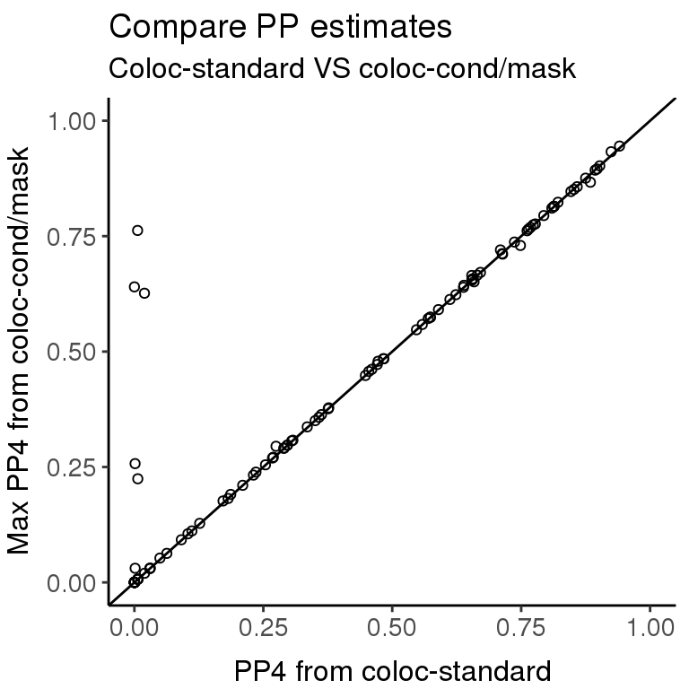

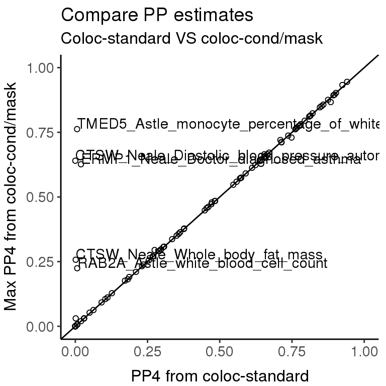